# Investigating the Correlation between Coral Bleaching and Reef Habitation Over Time (Final Project)

Jamie MacKinnon

7/18/2019

## Coral Bleaching and fish distribution

Explore how the distribution of moray eels, snapper fish, and angel fish are affected by coral bleaching in the Philippines. In years of heavy coral bleaching, how does the distribution of these species change?

In this document I will:

- Load data
- Filter data by years of high coral bleaching and low coral bleaching
- Map the locations of three marine species for these years
- Interpret the results to see how bleaching affects species distribution

### Required Packages

```r
library(sf)
library(rgdal)
library(ggplot2)
library(raster)
library(spatial)
library(dplyr)
library(mapr)
library(dismo)
library(spocc)
library(ENMeval)
library(tibble)
library(rinat)
library(maptools)
library(maps)
library(png)
library(grid)
```

### Years of Intense Coral Bleaching

Since 1985, the National Oceanic and Atmospheric Association has been posting daily images of coral bleaching hotspots around the world.

Here is an example of one of the daily images produced, highlighting the Philippines.

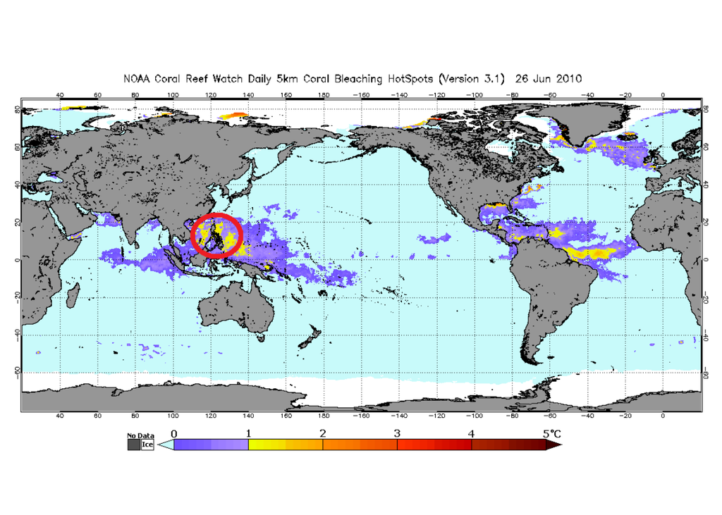

### Visualizing Hotspot Trends

In this project, NOAA images were used to visually determine which recent years contained the most intense coral bleaching; those years were 2010, 2014, 2015, and 2019, as shown by the yellow coloration on the maps of the Philippines below.

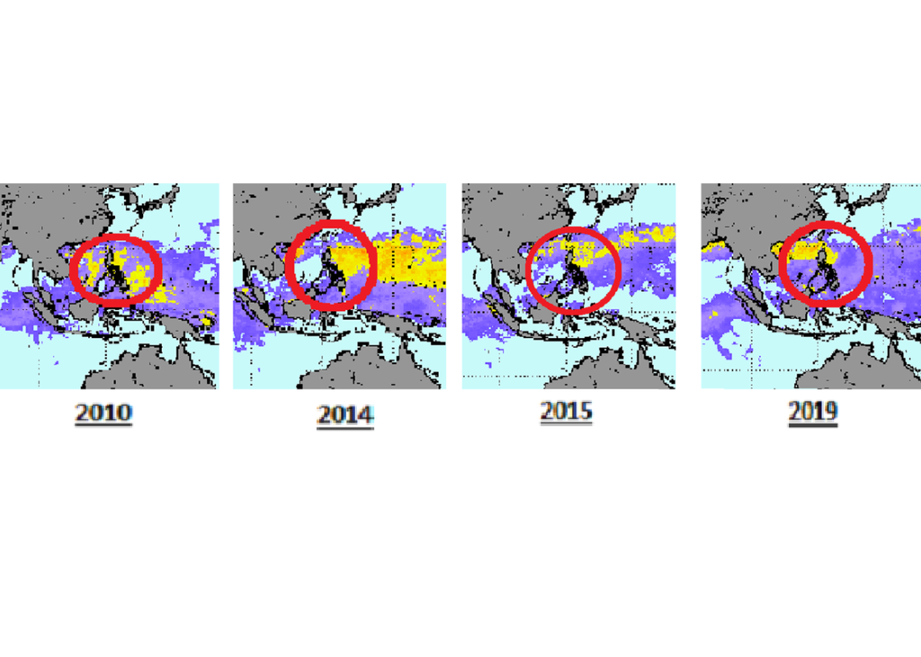

Years with much lower levels of bleaching were 2011, 2012, 2013, and 2018 (2016 had average bleaching).

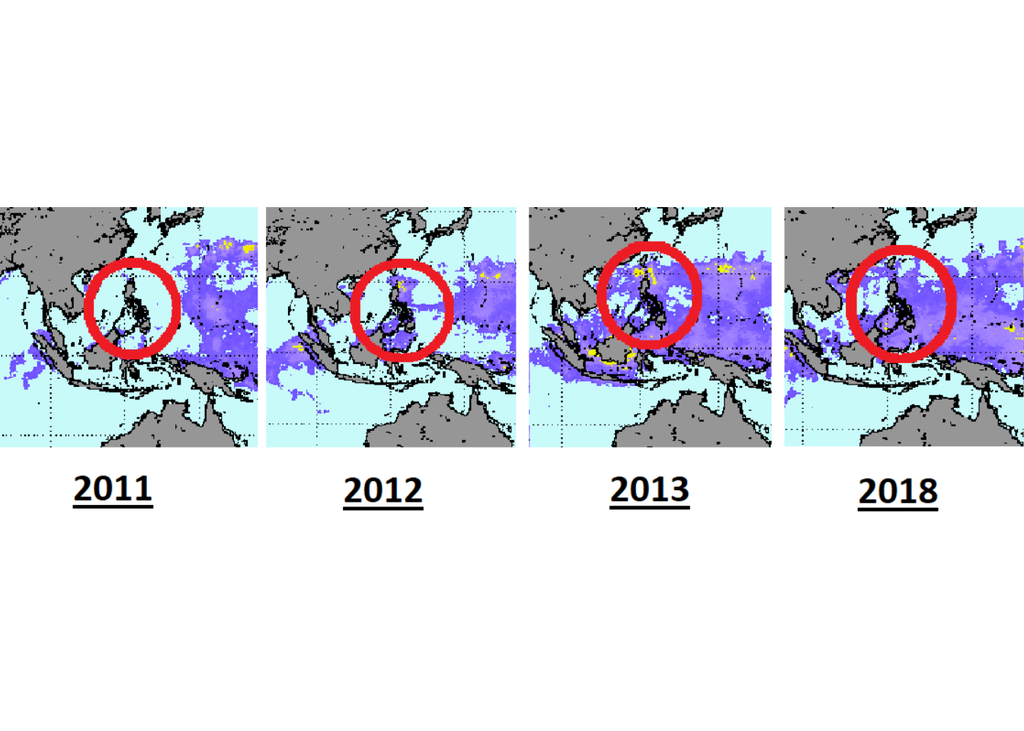

Occurance data for the three species of interest will be filtered by years of high or low bleaching and plotted to compare the differences in species distribution.

## Obtaining data from queries

The Phillipines reef ecosystems are home to many organisms, but three of the most abundant are moray eels, snapper fish, and angel fish. Using the gbif and iNaturalist resources, occurance data can be obtained and later plotted.